# 07 · Q4 Pulse 3: building a draft codebook of prompting approaches

How participants went about getting health help from AI, found by an LLM in 3 independent passes

Denicia Aragon Espinosa

November 04, 2026

## In short

- **What this step is.** We want a short list of the *ways* people go about getting health help from an AI. For example, how much they share about themselves, how they phrase a request, and how they follow up. A list like this, with clear rules for each category, is called a **codebook**. This report builds a **draft** of it. Nothing has been coded message by message yet.
- **How.** An LLM (Claude Opus 5.5, the model running this coding session) read all 53 chats that contain at least one participant message. It did this **3 separate times**, each time in a different random order and with no memory of the other passes. A 4th fresh session merged the three lists, keeping only approaches found in **at least 2 of the 3 passes**.
- **Result.** The draft has **11 approaches**, each found in at least 4 chats. 8 of them appeared in all 3 passes. 1 chat fits no approach.
- **Quote check.** 132 of 132 example quotes were found word for word in the participant’s own messages.
- **Next step: your review.** Read the draft codebook (section 6), edit it, then we pilot it, freeze it, and code every message 3 times.

Every prompt, input file and raw LLM output is saved in `output/07_build-codebook/`, so each step can be checked.

## Part A: the 7 pastes with no participant message

Before building the codebook, we re-read the 7 pastes that step 05 left with no participant (human) turns. We wanted to know whether any of them hides participant text that was coded as AI by mistake. We compared each one with the original paste (identical after removing spaces) and read it in full.

```r
part_a <- tribble(
  ~prolific_pid, ~verdict, ~evidence,
  "5fd63cb585f88c4eb1933661", "AI-only",
  "One AI reply about a cold medicine and diabetes; refers to the participant's images (\"the drug facts label in your second image\"); no participant text. Ends mid-list (\"3. Blood Glucose Monitor Interference\").",
  "62c4dbae8fb1ff9cd93a3150", "AI-only (several AI replies, participant's side missing)",
  "Three or four AI replies run together. The AI answers messages that were not pasted, e.g. \"Since it started just **yesterday**...\" and \"Loss of appetite along with nausea and tiredness for one day...\". No participant wording appears.",
  "62e7357284e65421d8f8b10f", "AI-only",
  "One AI reply about mucus in the throat, ending with the AI's own questions (\"Could you tell me: 1. How long has this been going on?\"). No participant text.",
  "6720084598df3cb5ac3ac3f2", "AI-only",
  "One AI sentence, partly repeated by the copy (\"A doctor will assess your medical history... to A doctor will assess...\"). Already noted in step 05.",
  "6a0497c25c04f83a27e1f07a", "AI-only",
  "One AI reply in Italian (\"Sì, questo è utile, ma non è un referto del tumore ovarico\"). Already noted in step 05.",
  "6a0e579710108dbe9059ee97", "AI-only",
  "One AI reply about a Baker's cyst (\"Since your Baker's cyst is being driven by cartilage wear...\"). No participant text.",
  "6ade720aea28ccfc1c990fee", "AI-only",
  "One short AI reply about high blood pressure (\"High blood pressure (hypertension) treatment depends on...\"). No participant text."
)
save_table(part_a, "partA_zero-message-pastes")
gt(part_a) |> cols_label(prolific_pid = "Prolific PID", verdict = "Verdict", evidence = "Evidence") |>
  cols_width(prolific_pid ~ px(230), verdict ~ px(200)) |> tab_options(table.font.size = px(16))
```

| Prolific PID | Verdict | Evidence |
| --- | --- | --- |
| 5fd63cb585f88c4eb1933661 | AI-only | One AI reply about a cold medicine and diabetes; refers to the participant's images ("the drug facts label in your second image"); no participant text. Ends mid-list ("3. Blood Glucose Monitor Interfe… |
| 62c4dbae8fb1ff9cd93a3150 | AI-only (several AI replies, participant's side missing) | Three or four AI replies run together. The AI answers messages that were not pasted, e.g. "Since it started just **yesterday**..." and "Loss of appetite along with nausea and tiredness for one day..."… |
| 62e7357284e65421d8f8b10f | AI-only | One AI reply about mucus in the throat, ending with the AI's own questions ("Could you tell me: 1. How long has this been going on?"). No participant text. |
| 6720084598df3cb5ac3ac3f2 | AI-only | One AI sentence, partly repeated by the copy ("A doctor will assess your medical history... to A doctor will assess..."). Already noted in step 05. |
| 6a0497c25c04f83a27e1f07a | AI-only | One AI reply in Italian ("Sì, questo è utile, ma non è un referto del tumore ovarico"). Already noted in step 05. |
| 6a0e579710108dbe9059ee97 | AI-only | One AI reply about a Baker's cyst ("Since your Baker's cyst is being driven by cartilage wear..."). No participant text. |
| 6ade720aea28ccfc1c990fee | AI-only | One short AI reply about high blood pressure ("High blood pressure (hypertension) treatment depends on..."). No participant text. |

**Verdict:** none of the 7 needs recoding. All 7 contain only AI text. These participants pasted the AI’s answer without their own question, even though the survey asked for “at least one message you wrote”. They stay out of the codebook, because there is no participant text to code.

## 1. Preparing the chats

Script: `scripts/07_build-codebook/07a_prepare_coding_input.py`

1. We took the corrected long file from step 05 and kept the **53 chats with at least 1 participant message** (147 messages).
2. We wrote each chat as a transcript, labelling every turn **Participant** or **AI**. Only participants’ words get coded. The AI replies are included because a follow-up such as “what about the second one?” only makes sense next to the reply it answers.
3. **Identifiers.** We searched for emails, ZIP codes and street addresses. We found 0. The only links and phone number in the chats are public (medical websites and a drug company’s helpline), so they were kept. The coding passes then noticed a few **first names** that this search cannot catch. So we added a de-identification step (**05b**, `scripts/05_build-conversation-dataset/05b_deidentify_names.py`). We read every message and replaced 4 personal names (36 mentions in 3 chats) with `[NAME]`, and this step now reads that de-identified file. The 3 passes and the merge were run *before* this change. Re-preparing the input from the de-identified file left the codebook, the chat orders and the quote check exactly the same, because no example quote contains a name. The original input the passes read is archived in `input/pre-deid_2026-11-04/`. It **contains names, so don’t share it**. The same goes for the raw pass and merge JSON files, whose notes mention the names. In this report, those names are shown as `[NAME]`. Cities, test dates and the insurer’s name were left in so you can decide about them.
4. **Shortening long AI replies.** An AI reply longer than 250 words was cut to its first 150 and last 100 words, and the cut is marked in the text. This kept each pass to about 38,000 words, which an LLM can read in one go. The end of a reply is kept because that is usually where the AI asks the participant something. Participant messages were never shortened.
5. **Three shuffled copies.** We made one copy of the full set per pass, each in its own random order, with fixed seeds 7001, 7002, 7003. Reading in a different order stops the earliest chats from shaping every pass the same way. The seeds mean the orders can be rebuilt exactly (`input/pass_orders.csv`).

## 2. Three independent passes

Script: `scripts/07_build-codebook/07b_write_pass_prompts.py` fills in `prompts/pass_prompt.md` for each pass.

Each pass was run in a **separate, fresh LLM session**. It could see only its own prompt and its own shuffled file, so no pass saw another pass’s answers. The prompt adapts the published procedure to our data:

- An **approach** is *what the participant was trying to get from the AI and how they went about getting it: what they shared about themselves, how they framed their requests, and how they followed up on the replies.*
- Find approaches, **not health topics**. Asking about knees versus blood pressure should not create two codes.
- **No example categories** are given, so the approaches come from the chats themselves.
- Each approach needs a definition, signs, how it differs from the closest approach, 2–3 verbatim quotes, and a list of the chats that show it. Keep only approaches seen in at least 3 chats, aiming for roughly 5–8.

Here is what each pass found:

```r
pass_codes |>
  arrange(pass, desc(n_chats)) |>
  mutate(pass = paste("Pass", pass)) |>
  select(pass, name, n_chats, merged_into) |>
  gt(groupname_col = "pass") |>
  cols_label(name = "Approach named by the pass", n_chats = "Chats", merged_into = "Merged into") |>
  tab_options(table.font.size = px(16), row_group.font.weight = "bold")
```

| Approach named by the pass | Chats | Merged into |
| --- | --- | --- |
| Pass 1 |  |  |
| Adding details to narrow the answer | 26 | A1 |
| Describing symptoms to ask the cause | 16 | A3 |
| Asking for general health facts | 13 | A4 |
| Asking what to do or take | 11 | A2 |
| Checking own hunch with the AI | 11 | A5 |
| Asking about seeing a doctor | 7 | A8 |
| Sharing results or materials to interpret | 6 | A11 |
| Front-loading personal context | 6 | A7 |
| Pushing back on the AI's read | 5 | A9 |
| Enlisting AI for writing or projects | 4 | A10 |
| Talking through stress and relationships | 3 | dropped |
| Pass 2 |  |  |
| Answering the AI's clarifying questions | 22 | A1 |
| Describing symptoms to ask why | 20 | A3 |
| Asking general health facts | 16 | A4 |
| Asking what to do about it | 13 | A2 |
| Testing own suspected explanation | 10 | A5 |
| Navigating professional care | 7 | A8 |
| Front-loading detailed personal context | 7 | A7 |
| Enlisting AI for a task or plan | 7 | A10 |
| Adding or updating information over time | 6 | A6 |
| Correcting or pushing back on the AI | 6 | A9 |
| Asking on behalf of someone else | 5 | dropped |
| Sharing results or documents to interpret | 4 | A11 |
| Pass 3 |  |  |
| Answering the AI's questions | 18 | A1 |
| Asking what to do next | 17 | A2 |
| Adding or correcting details unprompted | 15 | A6 |
| Asking a general information question | 14 | A4 |
| Describing symptoms to learn the cause | 13 | A3 |
| Testing a suspected cause | 10 | A5 |
| Giving a detailed personal brief | 8 | A7 |
| Commissioning a plan or document | 6 | A10 |
| Continuing an ongoing AI relationship | 5 | dropped |
| Asking AI to interpret results | 4 | A11 |

**Show the full pass prompt (pass 1)**

````
You are a qualitative researcher drafting a codebook from real conversations. This is pass 1 of 3 independent passes. Work only from the file named below. Do not open any other file in the project, and do not look for or read the output of any other pass.

## The data

`C:\Users\DeniciaAragon\OneDrive - Healogix\Q4_3_Pulse\output\07_build-codebook\input\pass_1_chats.txt` holds 53 conversations. In each one, a survey participant pasted a conversation they had had with an AI chatbot about a health question, for themselves or for someone else. The survey asked them to paste their most recent health conversation, including at least one message they wrote. The chats appear in a shuffled order (seed 7001).

- Each chat starts with `=== CHAT <chat_id> (...) ===` and ends with `=== END CHAT ===`.
- `[Participant, message n]:` lines are what the participant wrote. `[AI]:` lines are the chatbot's replies.
- Line breaks were lost when the survey was exported, so text may run together.
- Long AI replies are shortened, and the cut is marked `[... N words of the AI reply left out ...]`.

The file is about 225 KB. Read all of it before you start drafting. To read it in pieces, run Python, for example:
`C:\Users\DeniciaAragon\miniconda3\python.exe -c "t=open(r'C:\Users\DeniciaAragon\OneDrive - Healogix\Q4_3_Pulse\output\07_build-codebook\input\pass_1_chats.txt',encoding='utf-8').read(); print(t[0:40000])"`
and step through the file 40,000 characters at a time. If you use PowerShell, set `$env:PYTHONIOENCODING="utf-8"` first.

## What to find

Identify the **prompting approaches** that recur across these chats. A prompting approach is **what the participant was trying to get from the AI and how they went about getting it**: what they shared about themselves, how they framed their requests, and how they followed up on the replies.

- Find **approaches, not topics**. Questions about different illnesses, symptoms or medicines must not become separate codes just because the subject differs.
- No example categories are given on purpose. The approaches should come from the chats themselves.
- Code **only what participants wrote**. Read the AI replies as context, because a follow-up message often only makes sense next to the reply it answers.
- A chat can show more than one approach.
- An approach should **recur**: keep only approaches seen in at least 3 different chats. For 53 chats, roughly 5 to 8 approaches is a sensible size, but do not force or merge codes to reach that number.
- List any chats that fit none of your approaches.

For each approach, give:

1. `name`: a short, plain-language name of 2 to 6 words.
2. `definition`: 1 to 3 sentences. The first sentence must stand on its own as the definition.
3. `signs`: 2 to 5 concrete signs of the approach in participants' messages.
4. `closest_other`: the name of your most similar approach, and `how_it_differs` in one or two sentences.
5. `examples`: 2 or 3 example quotes from **different chats**, each with its `chat_id`. Each quote must be copied **exactly, character for character**, from a single `[Participant, message n]` line: one continuous stretch of 5 to 40 words. Never quote the AI. Do not fix spelling, punctuation or capitals, and do not join separate pieces with "...".
6. `chat_ids`: every chat that shows this approach. `n_chats` must equal the length of this list.

## Output

Write **only** valid JSON, in UTF-8, to `C:\Users\DeniciaAragon\OneDrive - Healogix\Q4_3_Pulse\output\07_build-codebook\passes\pass_1_raw_output.json`, with this exact structure:

```json
{
  "pass": 1,
  "seed": 7001,
  "n_chats_read": 53,
  "approaches": [
    {
      "name": "...",
      "definition": "...",
      "signs": ["...", "..."],
      "closest_other": "...",
      "how_it_differs": "...",
      "examples": [{"chat_id": "...", "quote": "..."}],
      "chat_ids": ["...", "..."],
      "n_chats": 0
    }
  ],
  "no_approach_chats": [{"chat_id": "...", "reason": "..."}],
  "notes": "Anything a researcher should know: borderline calls, approaches you saw in only 1-2 chats, any personal identifiers you noticed."
}
```

Write the file with Python's `json.dump(..., ensure_ascii=False, indent=2)`, which makes sure quotes inside the text are escaped. Then load it again to confirm that it is valid. Then check that every quote is found exactly in the input file and every `chat_id` exists, and fix anything that fails. Do not create any other files. Your final reply should be one short line confirming that the file was written, with the number of approaches.
````

## 3. Merging the passes

A 4th fresh session read only the three pass outputs and the participant messages (`prompts/merge_prompt.md`). It matched codes **by meaning, not by name**, and kept an approach only if **at least 2 of the 3 passes** found it. Codes found by just one pass are listed below. Any the merger thought worth a second look are flagged for you to decide on.

```r
if (nrow(dropped) > 0) {
  dropped |> mutate(worth_review = ifelse(worth_review, "Yes", "")) |>
    gt() |> cols_label(pass = "Pass", name = "Dropped code", reason = "Why", worth_review = "Worth your review?") |>
    tab_options(table.font.size = px(16))
} else cat("No pass code was dropped.")
```

| Pass | Dropped code | Why | Worth your review? |
| --- | --- | --- | --- |
| 1 | Talking through stress and relationships | Only pass 1 coded this (3 chats). Pass 2 noted the same pattern in 2 chats but did not code it; pass 3 coded parts of these chats as testing a suspected cause or a detailed personal brief. | Yes |
| 2 | Asking on behalf of someone else | Only pass 2 coded this. Passes 1 and 3 treated asking about a relative as a feature of other approaches (their definitions say 'their own or a family member's'). It describes whose health is asked abo… | Yes |
| 3 | Continuing an ongoing AI relationship | Only pass 3 coded this. Pass 1 mentioned memory across sessions in one chat (5eec8774) only; parts of these chats were coded as volunteering updates or enlisting AI for a project. | Yes |

**The merger’s notes:** Agreement was high: 8 of the 11 merged codes match directly across all three passes, often with the same example quotes. Disagreement was mainly about how finely to split two areas. (1) Action-seeking: pass 3 combined self-care questions with care navigation; passes 1 and 2 split them, so two codes were kept. (2) Follow-up turns: pass 1 combined answering AI questions with volunteered details, pass 3 combined volunteered updates with pushback, and pass 2 split all three. Three follow-up codes were kept; pilot coders should check that ‘Answering the AI’s clarifying questions’, ‘Volunteering updates on the situation’ and ‘Pushing back on the AI’s answer’ can be told apart reliably, and collapse updates and pushback if not. Other unclear boundaries: impersonal questions that are clearly about the participant’s own decision (e.g. 69d51123) may sit between general facts and asking what to do; ‘Does that make sense?’ turns (616f347d) between hunch-testing and pushback; plan requests (6a24b2df, 69a1ae3c) between asking what to do and enlisting AI for a task. Pass 1 and pass 3 left 66c0f464 (survey-style questions the AI answers in the first person) uncoded; pass 2 coded it as enlisting AI for a task. Chats 69c41892 and 6929d658 are largely non-health tasks. 66aafcc3 starts mid-conversation. Patterns noted by passes but not coded anywhere: terse keyword-style queries, persona or slang banter, and pasting outside articles as sources. All three passes flagged personal identifiers to redact before sharing: names [NAME], [NAME], [NAME] and [NAME], insurer Humana and drug costs (5eec8774), city Abuja (6ae359af), travel locations (5d7fd2a5) and exact test dates (6a9bb385, 69fe1811). One kept example quote (5eec8774) names the insurer Humana and a drug price; the researcher may prefer to redact it.

**How many chats have each approach?** Each pass placed chats under its own codes. For a merged approach, a chat **counts** if at least 2 of the 3 passes put it there. This is a majority vote, so one pass’s odd call cannot add or remove a chat.

## 4. Checking the example quotes

Script: `scripts/07_build-codebook/07c_check_and_build_codebook.py`

LLMs can tidy up or invent quotes. So a script checked every example quote, from all 3 passes and the merge. Each quote had to appear **word for word in a message the participant wrote, in the chat it is credited to**. Only spacing was allowed to differ, because the export had already merged line breaks into spaces.

```r
quotes |>
  group_by(source) |>
  summarise(quotes = n(), found_verbatim = sum(found_verbatim)) |>
  mutate(result = ifelse(found_verbatim == quotes, "all found", "SOME NOT FOUND")) |>
  gt() |> cols_label(source = "From", quotes = "Quotes", found_verbatim = "Found word for word", result = "") |>
  tab_options(table.font.size = px(16))
```

| From | Quotes | Found word for word |  |
| --- | --- | --- | --- |
| merge | 33 | 33 | all found |
| pass 1 | 33 | 33 | all found |
| pass 2 | 36 | 36 | all found |
| pass 3 | 30 | 30 | all found |

```r
fails <- filter(quotes, !found_verbatim)
if (nrow(fails) > 0) {
  fails |> select(source, code, chat_id, quote) |> gt() |> tab_options(table.font.size = px(15))
} else cat("Every quote was found word for word in the participant's own text.")
```

```
## Every quote was found word for word in the participant's own text.
```

## 5. How well the passes agreed

Two ways to read this table:

- **Found in passes:** how many of the 3 passes came up with the approach on their own.
- **Chat-level agreement:** whether the passes put the *same chats* under the approach. “All 3 agree” is the share of the 53 chats where the 3 passes gave the same answer (all yes or all no). **Fleiss’ kappa** does the same but removes the agreement you would expect by chance: 1 is perfect, 0 is chance level, and above about 0.6 is usually called good.

```r
agreement |>
  select(code, name, n_passes_found, chats_pass1, chats_pass2, chats_pass3, chats_majority,
         pct_chats_unanimous, fleiss_kappa) |>
  gt() |>
  cols_label(code = "", name = "Approach", n_passes_found = "Found in passes",
             chats_pass1 = "Pass 1", chats_pass2 = "Pass 2", chats_pass3 = "Pass 3",
             chats_majority = "Draft count (2+ passes)", pct_chats_unanimous = "All 3 agree",
             fleiss_kappa = "Fleiss' kappa") |>
  tab_spanner("Chats placed here by", columns = c(chats_pass1, chats_pass2, chats_pass3)) |>
  fmt_percent(pct_chats_unanimous, decimals = 0) |>
  tab_options(table.font.size = px(16))
```

[output not shown]

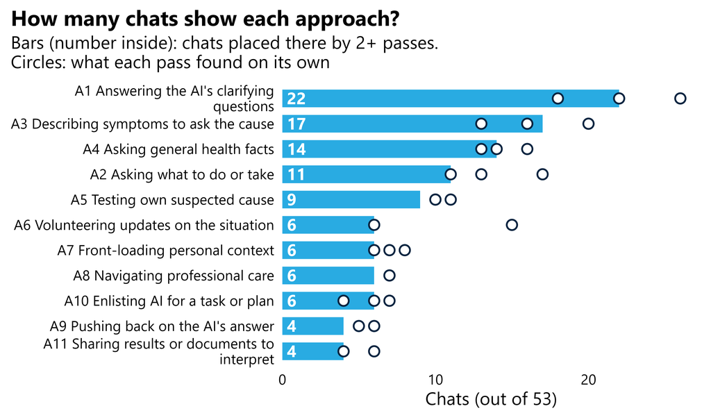

```r
plot_df <- agreement |>
  mutate(label = paste0(code, " ", name),
         label = factor(label, levels = rev(label)))
by_pass <- plot_df |>
  select(label, starts_with("chats_pass")) |>
  pivot_longer(-label, names_to = "pass", values_to = "chats") |>
  filter(chats > 0)  # 0 means that pass did not have the code at all

# the bar's count is printed in white inside the bar, so it never collides with the circles
p_appr <- ggplot(plot_df, aes(chats_majority, label)) +
  geom_col(fill = project_colors["clay"], width = 0.7) +
  geom_text(aes(x = 0.3, label = chats_majority), hjust = 0, size = 6.5,
            fontface = "bold", color = "white") +
  geom_point(data = by_pass, aes(chats, label), inherit.aes = FALSE,
             shape = 21, size = 4.5, fill = "white", color = project_colors["charcoal"], stroke = 1.4) +
  scale_x_continuous(expand = expansion(mult = c(0, 0.05))) +
  scale_y_discrete(labels = function(x) str_wrap(x, 40)) +
  labs(title = "How many chats show each approach?",
       subtitle = "Bars (number inside): chats placed there by 2+ passes.\nCircles: what each pass found on its own",
       x = paste0("Chats (out of ", settings$n_chats, ")"), y = NULL)
p_appr
```

```r
save_fig("chats-per-approach", p_appr, width = 11, height = 6.5)
```

## 6. The draft codebook

This is the part to review. For each approach: what it is, how to spot it, how it differs from its nearest neighbour, real examples (with the chat ID, the first 8 characters of the Prolific PID), and how many of the 53 chats show it. The same content is in `07_Q4_3_draft_codebook.xlsx` (sheet `codebook`), where you can edit it.

```r
codebook |>
  mutate(
    approach = paste0("**", code, ". ", name, "**<br><br>", n_chats, " chats<br>(passes ", found_in_passes, ")"),
    signs = str_replace_all(signs, "\n", "<br>"),
    differs = paste0("**vs. ", closest_other, ":** ", how_it_differs),
    examples = paste(example_1, example_2, example_3, sep = "<br><br>") |> str_remove("(<br><br>)+$")
  ) |>
  select(approach, definition, signs, differs, examples) |>
  gt() |>
  fmt_markdown(columns = everything()) |>
  cols_label(approach = "Approach", definition = "Definition", signs = "Signs in the messages",
             differs = "How it differs", examples = "Examples (chat ID)") |>
  cols_width(approach ~ px(190), definition ~ px(290), signs ~ px(290), differs ~ px(250), examples ~ px(330)) |>
  tab_options(table.font.size = px(17), data_row.padding = px(10), column_labels.font.weight = "bold") |>
  opt_row_striping()
```

Approach

Definition

Signs in the messages

How it differs

Examples (chat ID)

**A1. Answering the AI’s clarifying questions**  
22 chats  
(passes 1, 2, 3)

The participant replies to questions the AI asked, supplying the details it requested such as location, severity, duration, age or a choice among offered options. The AI steers the information gathering, and replies are often short fragments that only make sense next to the AI’s question.

- Reply directly follows an AI question  
  - Short answers: locations, ratings, letters or numbers  
  - Mirrors the options the AI offered  
  - Adds facts the participant had not volunteered

**vs. Volunteering updates on the situation:** Here the AI prompted the details; in ‘Volunteering updates on the situation’ the participant offers new information or changes on their own initiative.

“Back of neck, closer to shoulders” (5aeeb490)  
“Dull ache, feel weak when trying to stand up from sitting.” (69fb8bf7)  
“53, left leg, had sciatic and had surgery in April, pain for a few years” (66d9e5be)

**A3. Describing symptoms to ask the cause**  
17 chats  
(passes 1, 2, 3)

The participant describes a symptom or body change (their own or someone else’s) and asks the AI what is causing it or what it could be. The question is open-ended: they do not offer a suspected cause of their own, and the aim is an explanation rather than a plan of action.

- Lists symptoms, their location, duration or pattern  
  - Asks ‘what could be causing this?’, ‘what is wrong?’ or ‘what did I catch?’  
  - Can be a full account or a terse symptom phrase  
  - No named diagnosis offered by the participant

**vs. Testing own suspected cause:** Here the participant leaves the cause open; in ‘Testing own suspected cause’ they name a candidate explanation and ask the AI to confirm or rule it out.

“I have had an headache and vomitting for 2 days and pain behind my eyes what could be the problem” (6a9f047c)  
“Today I suddenly started feeling bad, fatigue, body aches, felt hot, later had the chills, nose is congested. What did I catch?” (664639e0)  
“Sometimes I wake up feeling like I haven’t rested at all. What could be causing this?” (63e55f08)

**A4. Asking general health facts**  
14 chats  
(passes 1, 2, 3)

The participant asks a factual, encyclopedia-style health question without tying it to their own case in that message. Questions ask what something is, what causes it, how common it is, what is normal, or what happens if it is untreated.

- Impersonal wording with no ‘I’ or ‘my’  
  - Reads like a search query or textbook question  
  - Asks for definitions, lists, norms or statistics  
  - May come before the participant later reveals a personal case

**vs. Describing symptoms to ask the cause:** General facts questions are not anchored to a described personal symptom; when the participant describes their own or a relative’s symptom and asks why, use ‘Describing symptoms to ask the cause’.

“please list every disease where fistula-in-anu is a symptom” (6658d49a)  
“What is the normal weight for a male who is 28 and five feet nine inches tall?” (6952e59d)  
“What if hand foot and mouth isn’t treated” (6a637176)

**A2. Asking what to do or take**  
11 chats  
(passes 1, 2, 3)

The participant asks the AI for practical steps they can take themselves: what to take, how to relieve a problem, whether a behaviour or product is safe, or how soon to resume an activity. The focus is self-management and action rather than explanation or contact with health services.

- ‘What should I take?’ or ‘what can I do to help?’  
  - Asks whether something is safe or advisable  
  - Asks about remedies, medicines, supplements or activity changes  
  - Asks how soon or how much

**vs. Navigating professional care:** This code covers actions the participant takes on their own; questions about whether, when or where to get professional care, or what will happen at an appointment, go to ‘Navigating professional care’.

“I have a headache, what should I take?” (69fd05bd)  
“what can i do to alleviate knee pain and get back to normal?” (69fb8bf7)  
“chat i have a really bad tummy ache, what can i do to help” (69ab73e1)

**A5. Testing own suspected cause**  
9 chats  
(passes 1, 2, 3)

The participant puts forward their own explanation, diagnosis or expectation and asks the AI to confirm, rule out or weigh it. The guess may concern a condition, a medicine side effect, a person’s behaviour or a likely outcome.

- ‘Could it be X?’ or ‘is it X or Y?’  
  - ‘I think I may have?’  
  - ‘Does that make sense?’ after offering an interpretation  
  - Asks whether an effect is typical of a named medicine

**vs. Describing symptoms to ask the cause:** The participant supplies a candidate answer for the AI to check; in ‘Describing symptoms to ask the cause’ the question is left open.

“Could it be gastritis? Tell me what causes gastritis and how long it can last.” (6a10664c)  
“Im feeling very bleh could it be that or flu?” (695be8c6)  
“Is that typical of the medicine or could it be related to the fact that he no longer takes melatonin?” (6144ea17)

**A6. Volunteering updates on the situation**  
6 chats  
(passes 2, 3)

After an earlier exchange, the participant returns on their own initiative with new facts or changes in their situation (new or easing symptoms, new events, news from others) and asks the AI to reassess. The conversation works as a running log of an unfolding situation.

- Reports change since the last message (‘feeling better today’, ‘starting to spread’)  
  - Brings news from outside the chat, such as a phone call or test  
  - Asks whether the AI still holds its earlier view  
  - Not prompted by an AI question

**vs. Pushing back on the AI’s answer:** Updates add new information about the situation; ‘Pushing back on the AI’s answer’ disputes or corrects what the AI already said.

“I’m feeling a bit better today, no aches or chills. Sore throat, no runny nose. Still think it’s the flu?” (664639e0)  
“The redness is starting to spread past my jaw but not yet to my neck. No issues breathing.” (6a21a961)  
“Bad news. I just called Humana back to double check that the price of my Prolia is truly going to drop to $55.43 next year” (5eec8774)

**A7. Front-loading personal context**  
6 chats  
(passes 1, 2, 3)

The participant opens with a long, detailed account of their own or a relative’s situation, such as age, weight, medicines, history, finances, goals and constraints, before or alongside the request. The detail is offered unprompted so the AI can tailor its answer, and the message reads like a case history.

- Opening message gives age, weight or body measurements  
  - Lists current medicines, supplements or routines  
  - Includes history, constraints or goals before the question  
  - Several questions or requirements packed into one message

**vs. Volunteering updates on the situation:** Front-loading happens at the start, before the AI replies; volunteered updates come later and report changes since an earlier exchange.

“I am a 24-year-old woman who weighs around 146 pounds and has recently started going to the gym more consistently.” (69a1ae3c)  
“My son started taking gaunfacine about a month ago and four days ago, upped the dose to 2mg.” (6144ea17)  
“I also drink around 100 oz of water per day as a 145 lb male who also fasts for about 18 hours each night” (69fcf529)

**A8. Navigating professional care**  
6 chats  
(passes 1, 2)

The participant asks whether, when or where to seek professional care, which specialist to see, or what to expect from an appointment, test, procedure or insurer. The AI is used to plan or prepare for contact with the health system.

- ‘Should I see a doctor/specialist or wait it out?’  
  - Asks which kind of specialist would help  
  - Asks what will happen at an upcoming appointment or test  
  - Asks about timing of calling a clinic or hospital, or about coverage

**vs. Asking what to do or take:** Here the next step involves health professionals or services; ‘Asking what to do or take’ covers things the participant does on their own.

“Should I see a medical specialist about this or try to wait it out?” (697cba85)  
“My eye doctor is sending me to a retina specialist, the appt is supposed to take 3-4 hours what will they do” (6a106089)  
“Would an endocrinologist benefit me from learning why my hormones are our of whack?” (6abae4ea)

**A10. Enlisting AI for a task or plan**  
6 chats  
(passes 1, 2, 3)

The participant asks the AI to produce or maintain something for them, such as a weight-loss or meal plan, a drafted message, an assignment, or an update to an ongoing project. The AI acts as an assistant producing a deliverable rather than an adviser answering a question.

- ‘Help me figure out a plan’ or ‘draft something’  
  - Asks for edits to text or a document  
  - Refers to an ongoing project to update  
  - Output is something to use, not an explanation

**vs. Asking what to do or take:** Here the participant wants a finished product from the AI; ‘Asking what to do or take’ seeks advice on a specific action.

“help me figure out a weight loss plan rn” (6a24b2df)  
“HELP ME CHOOSE A DEVELOPMENTAL CHANGE TO FOCUS ON” (69c41892)  
“Let’s incorporate this to improve the health and wellness project moving forward.” (66fd6acd)

**A9. Pushing back on the AI’s answer**  
4 chats  
(passes 1, 2)

The participant disputes, corrects or qualifies the AI’s previous reply, pointing to a fact it missed, a wrong assumption or a conclusion they doubt. The aim is to steer the AI back to what the participant sees as the relevant facts and get a revised answer.

- ‘But?’ or ‘keep in mind?’ after an AI reply  
  - States a fact that contradicts the AI’s assumption  
  - Tells the AI it has missed something  
  - Rejects the AI’s suggested explanation

**vs. Volunteering updates on the situation:** Pushback targets the AI’s reasoning or assumptions; updates report new developments without disputing what the AI said.

“but I can run without pain, I could start and stop with no real problem” (69fff128)  
“OK but keep in mind the diarrhea episodes before my vacation and during my vacation and now constant cramping in the lower abdomen.” (6a10664c)  
“Claude, you are missing a conversation. If the Prolia was truly $55.43, I would get it in a heartbeat, but the person who told me that was incorrect.” (5eec8774)

**A11. Sharing results or documents to interpret**  
4 chats  
(passes 1, 2, 3)

The participant pastes or uploads a test result, scan report, lab value, product label or other document and asks the AI to explain or use it. The shared material, not a symptom description, drives the question, and sometimes it is pasted with no question at all.

- Pasted report text, lab values or measurements  
  - Mentions an uploaded file, photo or label  
  - Asks what the results show or mean  
  - Material sent with little or no framing

**vs. Asking general health facts:** The question is anchored to a specific document or result the participant supplies; general facts questions are not tied to shared material.

“0.6 cm shadowing stone in the inferior pole of the right kidney.” (6a638cf5)  
“Convert to PDF So, at a high level what did these tests show?” (6a9bb385)  
“72 yo woman with 6.0 a1c” (66ec5904)

### Chats that fit no approach

```r
if (nrow(no_appr) > 0) {
  no_appr |>
    mutate(participant_text = str_trunc(participant_text, 300),
           why = coalesce(na_if(pass1_reason, ""), na_if(pass2_reason, ""), na_if(pass3_reason, ""), "")) |>
    select(chat_id, n_messages, participant_text, why) |>
    gt() |>
    cols_label(chat_id = "Chat", n_messages = "Messages", participant_text = "What the participant wrote (first 300 characters)",
               why = "A pass's reason") |>
    tab_options(table.font.size = px(16))
} else cat("Every chat fits at least one approach.")
```

| Chat | Messages | What the participant wrote (first 300 characters) | A pass's reason |
| --- | --- | --- | --- |
| 66c0f464 | 2 | What impact (if any) has taking a GLP-1A medication had on your physical health? \| What impact (if any) has taking a GLP-1A medication had on your mental health? | The participant asks the AI survey-style questions about what impact a GLP-1 medication has had on 'your' health, and the AI answers in the first person; the purpose is unclear (possibly having the AI… |

## 7. What happens next

This is a **draft**. The plan stops here until you have reviewed it. The remaining steps of the method are:

1. **Review and edit.** Rename, merge, split or drop approaches, and sharpen the definitions. Check the dropped codes marked “worth your review”. The draft has 11 approaches, which is more than the 5–8 we aimed for. Every pass also found 10–12, so the chats really do show many different moves. The codes the passes agreed on least (lowest kappa in section 5) are the first ones to merge or sharpen. For example, “Volunteering updates” and “Pushing back on the AI’s answer” are both ways of following up.
2. **Pilot and freeze.** Code a set of chats with the edited codebook, read the results, fix unclear rules, then freeze the codebook.
3. **Code every message 3 times.** The LLM codes each participant message with the frozen codebook three separate times, quoting its evidence. We keep each code that at least 2 of the 3 runs give.
4. **Hand-coding.** You will hand-code all chats, and we compare your codes with the LLM’s.

**Limits to keep in mind**

- **Small sample.** There are 53 chats. An approach seen in 3–5 chats rests on very few people.
- **Pasted past chats.** People chose what to paste, and some may have left out parts of the conversation.
- **Lost line breaks.** The export removed line breaks, so long pasted messages run together.
- **Shortened AI replies.** The coder saw shortened AI replies. This should not matter, because only participant text was coded, but the pilot should check it.

## Files written

All in `output/07_build-codebook/`:

- **`input/`**: `pass_1_chats.txt` to `pass_3_chats.txt` (rebuilt from the de-identified data), `chats.csv`, `participant_messages.csv`, `pass_orders.csv` (shuffled order and seed per pass), `redaction_log.csv`, `settings.json`. `input/pre-deid_2026-11-04/` holds the exact files the passes read, which **contain names, so don’t share them**.
- **`passes/`**: `pass_N_prompt.md` (exact prompt) and `pass_N_raw_output.json` (raw LLM output; the notes name people, **don’t share**)
- **`merge/`**: `merge_prompt.md` and `merge_raw_output.json` (the notes name people, **don’t share**)
- **Results:** `07_Q4_3_draft_codebook.xlsx` (sheets: codebook, pass_agreement, chat_codes, no_approach_chats, dropped_codes, pass_codes, quote_check, about), plus the same tables as CSVs, `partA_zero-message-pastes.csv`, `chats-per-approach.png`, and this report.